# Exercise 5

wenbo

## Conceptual

### Q1

$$\begin{aligned}
Var(\alpha X+(1-\alpha)Y)&=\alpha^2 Var(X)+(1-\alpha)^2Var(Y)+2\sigma_{\alpha X(1-\alpha)Y}\\
&=\alpha^2 \sigma_X^2+(1-\alpha)^2\sigma_Y^2+2\alpha(1-\alpha)\sigma_{XY} \\
&=\alpha^2(\sigma_X^2+\sigma_Y^2-2\sigma_{XY})-\alpha(2\sigma_{XY}-2\sigma_Y^2)+\sigma_Y^2
\end{aligned}$$
It can be seen that this is an quadratic equation of $\alpha$ and it can achieve one minimum value when $\alpha=\frac{-b}{2a}=\frac{\sigma_Y^2-\sigma_{XY}}{\sigma_X^2+\sigma_Y^2-2\sigma_{XY}}$

### Q2

#### (a)

$$P=\frac{n-1}{n}$$

#### (b)

$$P=\frac{n-1}{n}$$

#### (c)

since the we have calculated the probability that the i-th (i can be any number from 1 to n) bootstrap ovservation is not the j-th observation form original sample is $P=\frac{n-1}{n}$, we can do a multiply:
$$P=\frac{n-1}{n}\frac{n-1}{n}...\frac{n-1}{n}=(\frac{n-1}{n})^n$$

#### (d)

$$p=1-(\frac{5-1}{5})^5\approx 0.67$$

#### (e)

$$p=1-(\frac{100-1}{100})^100\approx 0.63$$

#### (f)

$$p=1-(\frac{10000-1}{10000})^10000\approx 0.63$$

#### (g)

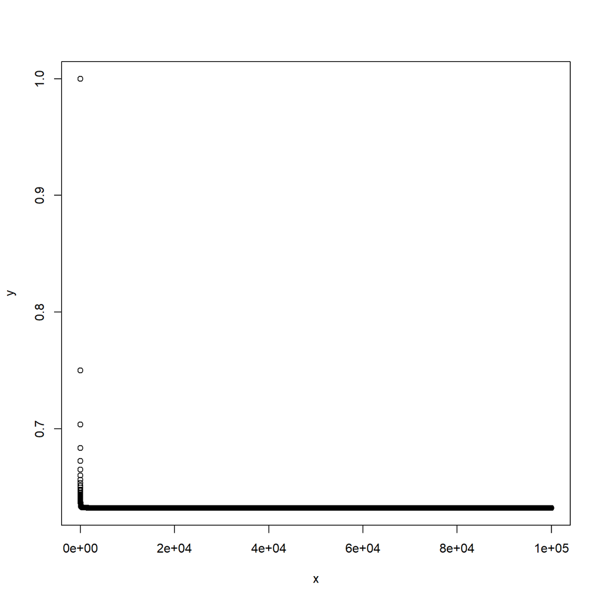

```r
x=1:100000
y=rep(0,100000)
for(i in 1:100000){
  y[i]=1-((i-1)/i)^i
}
plot(x,y)
```

When n become larger, the probability will converge.

#### (h)

```r
store=rep(NA,10000)
for(i in 1:10000){
  store[i]=sum(sample(1:100,rep=TRUE)==4)>0
}
mean(store)
```

```
## [1] 0.6269
```

Almost 63% bootstrap dataset contain 4-th observation and this numerical result is close to the theoretical probability we obtained in (g).

### Q3

#### (a)

First, we can shuffle the whole dataset, then we split it into 10 folds. Each time, we use one 9 folds as training dataset and the remaining one as validation set. We can repeat this process 10 times and obtain 10 results. Finally, average them.

#### (b)

##### i

advantage:Less bias \ disadvantage: More computational cost

##### ii

advantage: Computational advantage, less variance and more accurate estimate. disadvantage: More bias.

### Q4

We can use bootstrap to estimate the standard deviationof prediction.

## Applied

### Q5

#### (a)

```r
library(ISLR)
glm.fit=glm(default~income+balance,data=Default,family=binomial)
```

#### (b)

```r
set.seed(1)
train=sample(dim(Default)[1],round(dim(Default)[1]/2),replace=FALSE)
glm.fit1=glm(default~balance+income,data=Default,subset=train,family=binomial)
prob1=predict(glm.fit1,Default[-train,],type='response')
class1=rep('No',length(prob1))
class1[prob1>0.5]='Yes'
mean(class1==Default$default[-train])
```

```
## [1] 0.9746
```

Test error is about 0.03.

#### (c)

```r
result=rep(0,3)
for (i in 2:4){
  set.seed(i)
  train=sample(dim(Default)[1],round(dim(Default)[1]/2),replace=FALSE)
  glm.fit1=glm(default~balance+income,data=Default,subset=train,family=binomial)
  prob1=predict(glm.fit1,Default[-train,],type='response')
  class1=rep('No',length(prob1))
  class1[prob1>0.5]='Yes'
  result[i-1]=mean(class1==Default$default[-train])
}
```

[output not shown]

All the prediction accuracies are close to 97%.

#### (d)

```r
set.seed(1)
train=sample(dim(Default)[1],round(dim(Default)[1]/2),replace=FALSE)
glm.fit1=glm(default~balance+income+student,data=Default,subset=train,family=binomial)
prob1=predict(glm.fit1,Default[-train,],type='response')
class1=rep('No',length(prob1))
class1[prob1>0.5]='Yes'
mean(class1==Default$default[-train])
```

```
## [1] 0.974
```

Adding dummy variable for studentswill not lead to a reduction in the test error.

### Q6

#### (a)

```r
glm.fit=glm(default~income+balance,data=Default,family=binomial)
summary(glm.fit)
```

```
##
## Call:
## glm(formula = default ~ income + balance, family = binomial,
##     data = Default)
##
## Deviance Residuals:
##     Min       1Q   Median       3Q      Max
## -2.4725  -0.1444  -0.0574  -0.0211   3.7245
##
## Coefficients:
##               Estimate Std. Error z value Pr(>|z|)
## (Intercept) -1.154e+01  4.348e-01 -26.545  < 2e-16 ***
## income       2.081e-05  4.985e-06   4.174 2.99e-05 ***
## balance      5.647e-03  2.274e-04  24.836  < 2e-16 ***
## ---
## Signif. codes:  0 '***' 0.001 '**' 0.01 '*' 0.05 '.' 0.1 ' ' 1
##
## (Dispersion parameter for binomial family taken to be 1)
##
##     Null deviance: 2920.6  on 9999  degrees of freedom
## Residual deviance: 1579.0  on 9997  degrees of freedom
## AIC: 1585
##
## Number of Fisher Scoring iterations: 8
```

Standard errors for income and balance are 4.985e-06 and 2.274e-04.

#### (b)

```r
boot.fn<-function(data,index){
  return(coef(glm(default~income+balance,data=data,subset=index,family=binomial)))
}
```

#### (c)

```r
library(boot)
set.seed(1)
boot(Default,boot.fn,100)
```

```
##
## ORDINARY NONPARAMETRIC BOOTSTRAP
##
##
## Call:
## boot(data = Default, statistic = boot.fn, R = 100)
##
##
## Bootstrap Statistics :
##          original        bias     std. error
## t1* -1.154047e+01  8.556378e-03 4.122015e-01
## t2*  2.080898e-05 -3.993598e-07 4.186088e-06
## t3*  5.647103e-03 -4.116657e-06 2.226242e-04
```

#### (d)

It can be seen that bootstrap method could provide similar results with standard formula.

### Q7

#### (a)

```r
glm.fit1=glm(Direction~Lag1+Lag2,data=Weekly,family=binomial)
```

#### (b)

```r
glm.fit2=glm(Direction~Lag1+Lag2,data=Weekly[-1,],family=binomial)
```

#### (c)

```r
prob=predict(glm.fit2,Weekly[1,],type='response')
predict=prob>0.5
predict==Weekly[1,]$Direction
```

```
##     1
## FALSE
```

No, wrong classification.

#### (d)

```r
length=dim(Weekly)[1]
result=rep(0,length)
for(i in 1:length){
glm.fit2=glm(Direction~Lag1+Lag2,data=Weekly[-i,],family=binomial)
prob=predict(glm.fit2,Weekly[i,],type='response')
if(predict>0.5){
  predict='Up'
}
else{predict='Down'}
result[i]=mean(predict!=Weekly[i,]$Direction)
}
```

#### (e)

```r
mean(result)
```

```
## [1] 0.4444444
```

error rate is about 0.44.

### Q8

#### (a)

```r
set.seed(1)
y=rnorm(100)
x=rnorm(100)
y=x-2*x^2+rnorm(100)
```

n is 100 and p is 1.

$$y=-2x^2+x+\epsilon$$
This is a polynomial regression model where $\epsilon$ follows N(0,1)

#### (b)

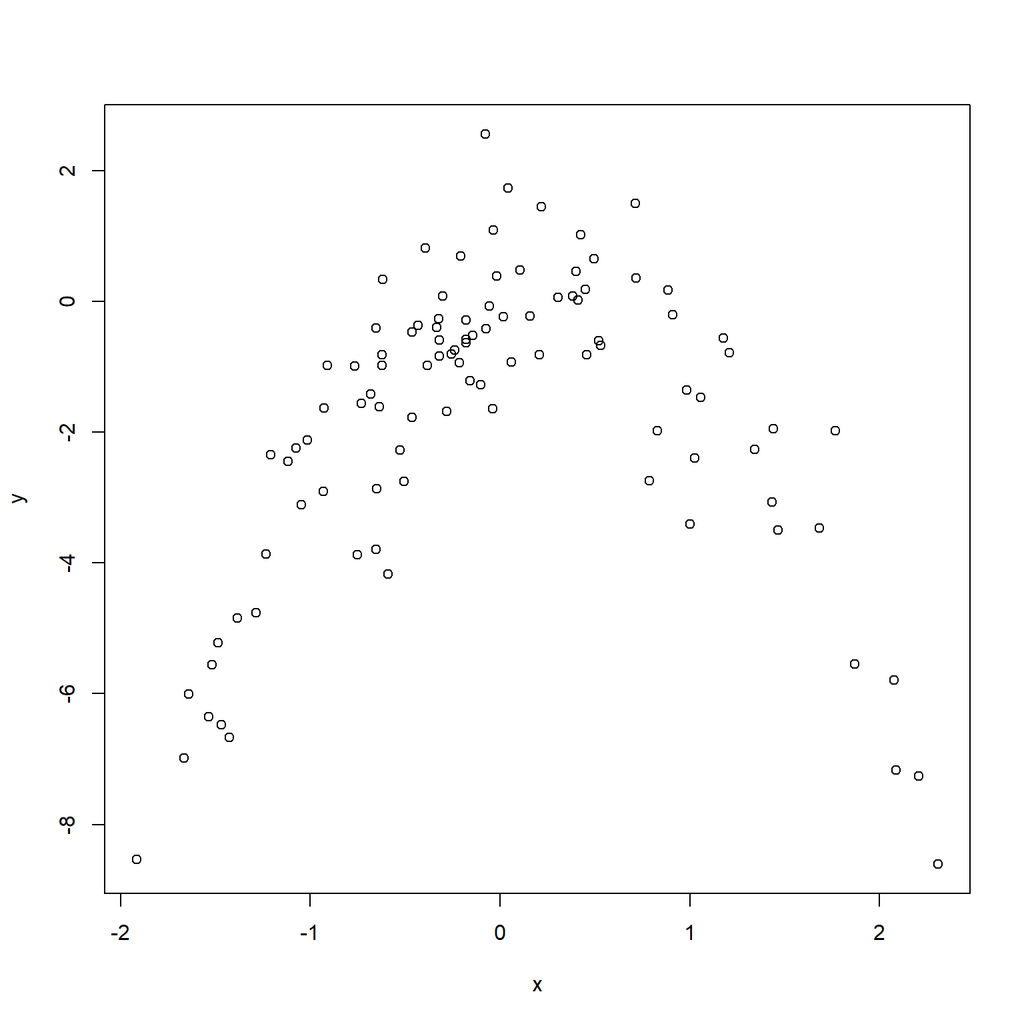

```r
plot(x,y)
```

y has a quadratic shape of x.

#### (c)

```r
set.seed(1)
error1=rep(0,4)
da=data.frame(x,y)
for(i in 1:4){
  length=dim(da)[1]
  result=0
  for(j in 1:length){
    lm.fit2=lm(y~poly(x,i),data=da[-j,])
    predict=predict(lm.fit2,da[j,])
    result=result+(predict-da$y[j])^2
  }
  error1[i]=result
}
error1
```

```
## [1] 589.0979 108.6596 110.2585 111.4772
```

#### (d)

```r
set.seed(2)
error2=rep(0,4)
da=data.frame(x,y)
for(i in 1:4){
  length=dim(da)[1]
  result=0
  for(j in 1:length){
    lm.fit2=lm(y~poly(x,i),data=da[-j,])
    predict=predict(lm.fit2,da[j,])
    result=result+(predict-da$y)^2
  }
  error2[i]=result
}
error2
```

```
## [1]  74.40974 518.92721 517.57673 521.87891
```

#### (f)

```r
lm.fit2=lm(y~poly(x,i),data=da)
summary(lm.fit2)
```

```
##
## Call:
## lm(formula = y ~ poly(x, i), data = da)
##
## Residuals:
##     Min      1Q  Median      3Q     Max
## -2.8914 -0.5244  0.0749  0.5932  2.7796
##
## Coefficients:
##             Estimate Std. Error t value Pr(>|t|)
## (Intercept)  -1.8277     0.1041 -17.549   <2e-16 ***
## poly(x, i)1   2.3164     1.0415   2.224   0.0285 *
## poly(x, i)2 -21.0586     1.0415 -20.220   <2e-16 ***
## poly(x, i)3  -0.3048     1.0415  -0.293   0.7704
## poly(x, i)4  -0.4926     1.0415  -0.473   0.6373
## ---
## Signif. codes:  0 '***' 0.001 '**' 0.01 '*' 0.05 '.' 0.1 ' ' 1
##
## Residual standard error: 1.041 on 95 degrees of freedom
## Multiple R-squared:  0.8134, Adjusted R-squared:  0.8055
## F-statistic: 103.5 on 4 and 95 DF,  p-value: < 2.2e-16
```

Yes, the results agree with the conclusion.

### Q9

#### (a)

```r
library(MASS)
mean(Boston$medv)
```

```
## [1] 22.53281
```

#### (b)

```r
sd(Boston$medv)/sqrt(dim(Boston)[1]-1)
```

```
## [1] 0.4092658
```

standard error measures how far the sample mean of the data is likely to be from the true population mean

#### (c)

```r
mu<-function(data,index){
  return(mean(data$medv[index]))
}
boot(Boston,mu,100)
```

```
##
## ORDINARY NONPARAMETRIC BOOTSTRAP
##
##
## Call:
## boot(data = Boston, statistic = mu, R = 100)
##
##
## Bootstrap Statistics :
##     original      bias    std. error
## t1* 22.53281 -0.05943281   0.3972639
```

The two results are very close.

#### (d)

```r
t.test(Boston$medv)
```

```
##
##  One Sample t-test
##
## data:  Boston$medv
## t = 55.111, df = 505, p-value < 2.2e-16
## alternative hypothesis: true mean is not equal to 0
## 95 percent confidence interval:
##  21.72953 23.33608
## sample estimates:
## mean of x
##  22.53281
```

```r
c(mean(Boston$medv)-2*0.429,mean(Boston$medv)+2*0.429)
```

```
## [1] 21.67481 23.39081
```

The two confidence intervals are very close.

#### (e)

```r
median(Boston$medv)
```

```
## [1] 21.2
```

#### (f)

```r
mu<-function(data,index){
  return(median(Boston$medv[index]))
}
boot(Boston,mu,100)
```

```
##
## ORDINARY NONPARAMETRIC BOOTSTRAP
##
##
## Call:
## boot(data = Boston, statistic = mu, R = 100)
##
##
## Bootstrap Statistics :
##     original  bias    std. error
## t1*     21.2  0.0195   0.3888532
```

#### (g)

```r
quantile(Boston$medv,0.1)
```

```
##   10%
## 12.75
```

#### (h)

```r
mu<-function(data,index){
  return(quantile(Boston$medv[index],0.1))
}
boot(Boston,mu,100)
```

```
##
## ORDINARY NONPARAMETRIC BOOTSTRAP
##
##
## Call:
## boot(data = Boston, statistic = mu, R = 100)
##
##
## Bootstrap Statistics :
##     original  bias    std. error
## t1*    12.75   0.038   0.4519945
```